# Assignment 4 - Task 1

Author

Meet Muchhala

# 1 Wind Power Development Sites: Principal Component Analysis

## 1.1 Overview

The primary objective of this analysis is to conduct a Principal Components Analysis (PCA) on the provided dataset. PCA enables us to identify underlying patterns and relationships within the data, particularly focusing on how accessibility to cities relates to other wind variables globally. The insights gained from this analysis will aid in understanding the potential impact of accessibility to cities on wind energy installations and development across different regions.

## 1.2 Dataset Summary

The dataset utilized for this analysis comprises miscellaneous environmental and climatic variables at the country level. Compiled by @zander_venter and sourced from Kaggle, the dataset encompasses a range of metrics obtained from Google Earth Engine. These metrics are derived by calculating means for each country at a reduced scale of approximately 10km.

Data Citation: Venter, Zander. (2018). Environmental variables for world countries. Retrieved 2024-02-02 from Kaggle.

Pseudocode Outline * Load the dataset and preprocess it by handling missing values and assigning factor levels to the “accessibility_to_cities” column. * Perform PCA analysis on selected wind-related variables. * Determine the loadings of each principal component. *Generate a biplot to visualize the relationships between variables and observations.* Create a screeplot to assess the variance explained by each principal component.

## 1.3 Setting up libraries

```r
library(tidyverse)
library(here)
library(ggfortify)
```

## 1.4 Setting up data

```r
## Loading the dataset

world_env_vars <- read_csv(here('data', 'world_env_vars.csv'))

## Dropping NAs due to PCA analysis and assigning factor levels to accessibility column
world_env_vars_clean <- world_env_vars %>%
  janitor::clean_names() %>%
  drop_na() %>%
  mutate(accessibility_to_cities =
                     case_when(accessibility_to_cities <= 100 ~ "Very High",
                              accessibility_to_cities <= 500 ~ "High",
                              accessibility_to_cities <= 1000 ~ "Medium",
                              accessibility_to_cities <= 11000 ~ "Low")) %>%
  mutate(accessibility_to_cities = factor(accessibility_to_cities, levels = c('Low', 'Medium', 'High', 'Very High')))


#glimpse(world_env_vars_clean)
#names(world_env_vars_clean)
```

## 1.5 PCA Analysis & Bi-plot

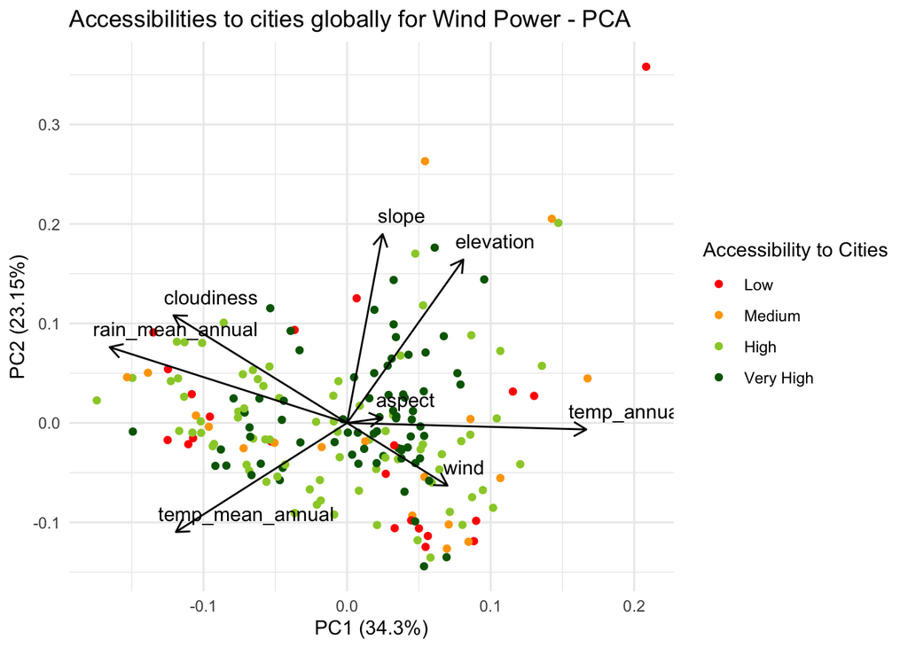

Figure 1: Bi-Plot exploring the relationships across chosen variables for wind power accessibility in cities across Principal Component 1 and Principal Component 2.

```r
## Selecing relevant variables in case of building PCA analysis for wind energy installations and development country-wise

env_var_pca <- world_env_vars_clean %>%
  select(wind, elevation, aspect, slope, rain_mean_annual,
         temp_mean_annual, temp_annual_range, cloudiness) %>%
  select(where(is.numeric)) %>%
  prcomp(scale = TRUE)

#env_var_pca$rotation

autoplot(env_var_pca,
        data = world_env_vars_clean,
        loadings = TRUE,
        colour = 'accessibility_to_cities',
        loadings.label = TRUE,
        loadings.colour = "black",
        loadings.label.colour = "black",
        loadings.label.vjust = -0.8,
        loadings.label.hjust = 0.1
        ) +
  ggtitle("Accessibilities to cities globally for Wind Power - PCA") +
  guides(color = guide_legend(title = "Accessibility to Cities")) +
  scale_color_manual(values = c('red', 'orange', 'yellowgreen', 'darkgreen')) +
  theme_minimal()
```

## 1.6 Screeplot of the analysis

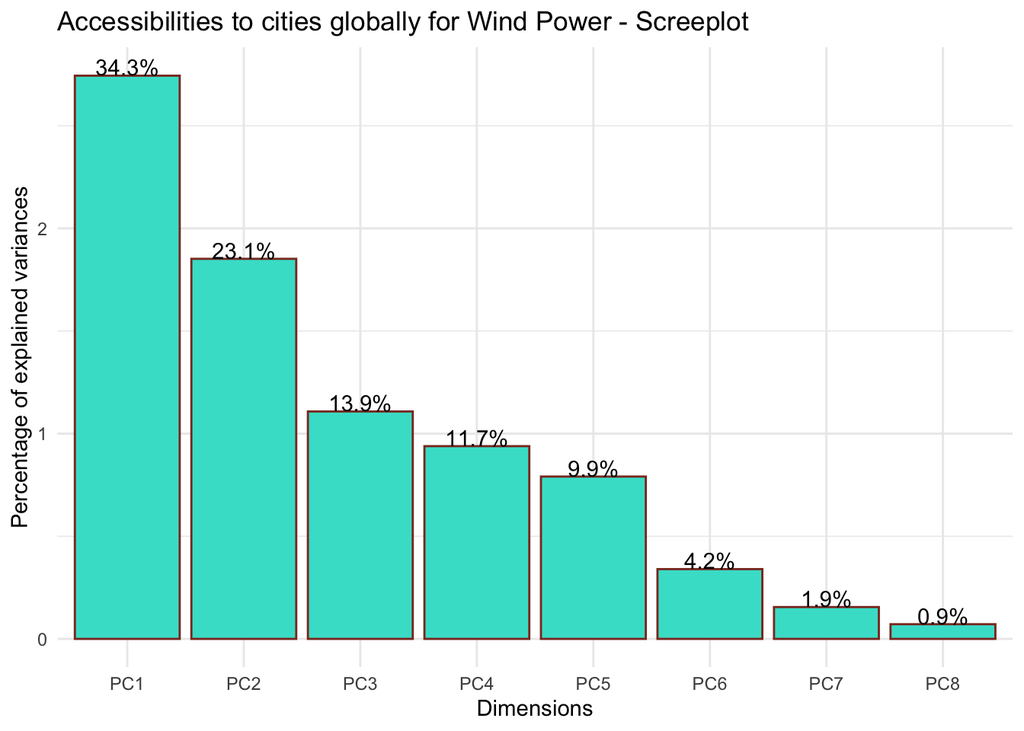

Figure 2: Screeplot describing the variances explained by each principal component.

```r
sd_vec <- env_var_pca$sdev
var_vec <- sd_vec^2 ### standard deviation is sqrt of variance
pc_names <- colnames(env_var_pca$rotation)
pct_expl_df <- data.frame(v = var_vec,
                          pct_v = var_vec / sum(var_vec),
                          pc = fct_inorder(pc_names)) %>%
  mutate(pct_lbl = paste0(round(pct_v*100, 1), '%'))

ggplot(pct_expl_df, aes(x = pc, y = v)) +
  geom_col(color = "tomato4", fill = "turquoise") +
  ggtitle("Accessibilities to cities globally for Wind Power - Screeplot")+
  geom_text(aes(label = pct_lbl), vjust = 0, nudge_y = .002) +
  labs(x = 'Dimensions', y = 'Percentage of explained variances')+
  theme_minimal()
```

## 1.7 Summary & Conclusion

- Mean annual rainfall and Annual temprature are negatively correlated. These two variables also have fairly long arrows, indicating larger variance.
- Mean annual rainfall and cloudiness are the most closely correlated; more rain is correlated with more cloudiness.
- Aspect has the shortest arrow, indicating less variance.
- There may be some clustering of the “Very High” accessibility observations, as seen around the Annual temperature and wind arrow.
- The screeplot indicates four PCAs explain more than 80% of the variance. This may be a good cutoff point, beyond which additional components may not be as useful.